# Q1) What are the busiest times of the year to visit Seattle? By how much do prices spike?

Table of contents

1. Busy times
2. Prices

```python
import numpy as np
import pandas as pd
import lightgbm as lgb
import os
from jupyterthemes import jtplot
from datetime import datetime
import seaborn as sns

import matplotlib.pyplot as plt
%matplotlib inline
jtplot.style(theme='solarizedd')
plt.rcParams['figure.figsize'] = (20.0, 10.0)

%load_ext autoreload
%autoreload 2

ROOT_DIR = '..'
DATA_DIR = os.path.join(ROOT_DIR, 'data')
DATA_RAW = os.path.join(DATA_DIR, 'raw')
DATA_INTERIM = os.path.join(DATA_DIR, 'interim')
DATA_EXTERNAL = os.path.join(DATA_DIR, 'external')

SRC_DIR = os.path.join(ROOT_DIR, 'src')

SEATTLE_LISTINGS_COLS = os.path.join(
    DATA_INTERIM, 'seattle', 'listings_cols_df.pkl')

import sys
sys.path.append(SRC_DIR)
sys.path.append(os.path.join(SRC_DIR, 'data'))

import preprocessing as pp
import missing_data as md
import make_dataset
```

```
The autoreload extension is already loaded. To reload it, use:
  %reload_ext autoreload
```

```python
# If the dataset is already processed comment the line below
# make_dataset.create_dataset()
calendar, listings, reviews = make_dataset.load_processed()
```

```python
listings_cols_df = pd.read_pickle(SEATTLE_LISTINGS_COLS)
```

## 1. Busy times

Top

```python
calendar.head()
```

|  | listing_id | date | available | price |
| --- | --- | --- | --- | --- |
| 0 | 241032 | 2016-01-04 | True | 85.0 |
| 1 | 241032 | 2016-01-05 | True | 85.0 |
| 2 | 241032 | 2016-01-06 | False | 85.0 |
| 3 | 241032 | 2016-01-07 | False | 85.0 |
| 4 | 241032 | 2016-01-08 | False | 85.0 |

Let's convert that to a time series of availability

```python
avail_ts = calendar.pivot_table(index='date',
                                columns='listing_id',
                                values='available',
                                aggfunc=lambda x: x)
print(avail_ts.shape)
avail_ts.head()
```

```
(365, 3818)
```

| listing_id date | 3335 | 4291 | 5682 | 6606 | 7369 | 9419 | 9460 | 9531 | 9534 | 9596 | ... | 10309898 | 10310373 | 10318171 | 10319529 | 10331249 | 10332096 | 10334184 | 10339144 | 10339145 | 10340165 |
| --- | --- | --- | --- | --- | --- | --- | --- | --- | --- | --- | --- | --- | --- | --- | --- | --- | --- | --- | --- | --- | --- |
| 2016-01-04 | False | True | False | True | False | True | True | False | False | True | ... | True | False | False | False | False | True | False | False | True | False |
| 2016-01-05 | False | True | False | True | False | True | True | False | False | True | ... | True | False | True | False | False | True | False | False | True | False |
| 2016-01-06 | False | True | False | True | False | True | False | False | False | True | ... | True | False | True | False | False | True | False | False | True | False |
| 2016-01-07 | False | True | False | True | False | True | False | False | False | True | ... | True | False | True | False | False | True | False | False | True | False |
| 2016-01-08 | False | True | False | True | False | True | False | False | False | True | ... | True | True | True | False | False | True | True | False | True | False |

5 rows × 3818 columns

```
Text(0.5,1,'Percentage of available listings')
```

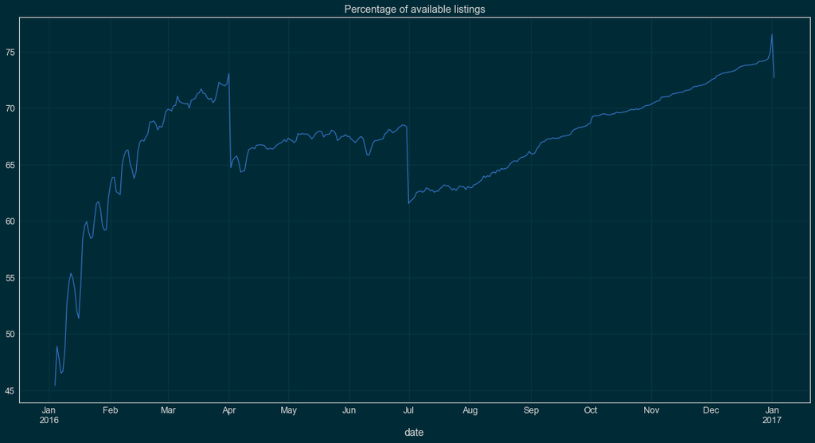

```python
(100 * avail_ts.mean(axis=1)).plot()
plt.title('Percentage of available listings')
```

The first three months have low availability because we are very close from the reservation date. So, the busiest times of the year seem to be between July and August.

## 2. Prices

Top

Let's now make a prices time series

```python
price_ts = calendar.pivot_table(index='date',
                                columns='listing_id',
                                values='price')
print(price_ts.shape)
price_ts.head()
```

```
(365, 3818)
```

| listing_id date | 3335 | 4291 | 5682 | 6606 | 7369 | 9419 | 9460 | 9531 | 9534 | 9596 | ... | 10309898 | 10310373 | 10318171 | 10319529 | 10331249 | 10332096 | 10334184 | 10339144 | 10339145 | 10340165 |
| --- | --- | --- | --- | --- | --- | --- | --- | --- | --- | --- | --- | --- | --- | --- | --- | --- | --- | --- | --- | --- | --- |
| 2016-01-04 | 120.0 | 82.0 | 50.0 | 90.0 | 85.0 | 70.0 | 109.0 | 165.0 | 125.0 | 120.0 | ... | 250.0 | 20.0 | 50.0 | 49.0 | 45.0 | 40.0 | 120.0 | 60.0 | 219.0 | 43.0 |
| 2016-01-05 | 120.0 | 82.0 | 50.0 | 90.0 | 85.0 | 70.0 | 109.0 | 165.0 | 125.0 | 120.0 | ... | 250.0 | 20.0 | 50.0 | 49.0 | 45.0 | 40.0 | 120.0 | 60.0 | 219.0 | 43.0 |
| 2016-01-06 | 120.0 | 82.0 | 50.0 | 90.0 | 85.0 | 70.0 | 109.0 | 165.0 | 125.0 | 120.0 | ... | 250.0 | 20.0 | 50.0 | 49.0 | 45.0 | 40.0 | 120.0 | 60.0 | 219.0 | 43.0 |
| 2016-01-07 | 120.0 | 82.0 | 50.0 | 90.0 | 85.0 | 70.0 | 109.0 | 165.0 | 125.0 | 120.0 | ... | 250.0 | 20.0 | 50.0 | 49.0 | 45.0 | 40.0 | 120.0 | 60.0 | 219.0 | 43.0 |
| 2016-01-08 | 120.0 | 82.0 | 50.0 | 100.0 | 85.0 | 70.0 | 109.0 | 165.0 | 125.0 | 125.0 | ... | 250.0 | 20.0 | 50.0 | 49.0 | 45.0 | 40.0 | 120.0 | 60.0 | 219.0 | 43.0 |

5 rows × 3818 columns

What about the mean price?

```
Text(0.5,1,'Mean price in time')
```

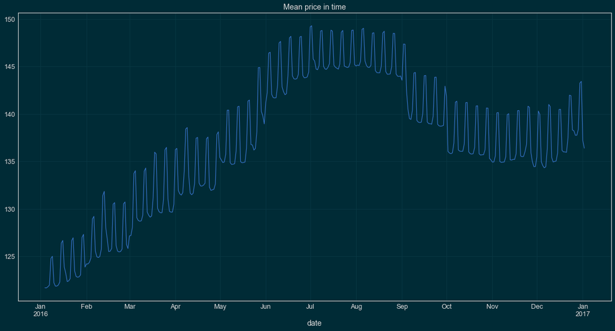

```python
mean_price = price_ts.mean(axis=1)
mean_price.plot()
plt.title('Mean price in time')
```

It clearly has a weekly seasonality. Let's try to extract it.

```
Text(0,0.5,'Percentage of price variation (%)')
```

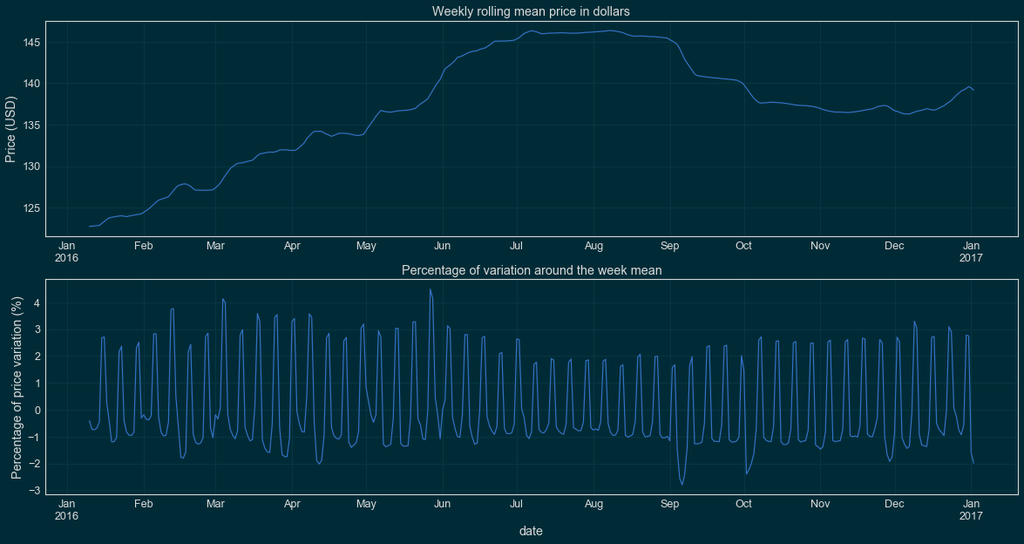

```python
rows, cols = (2, 1)

week_mean = mean_price.rolling(7).mean()
plt.subplot(rows, cols, 1)
week_mean.plot()
plt.title('Weekly rolling mean price in dollars')
plt.ylabel('Price (USD)')
plt.xlabel('')

weekly_price = (mean_price - week_mean) / week_mean
plt.subplot(rows, cols, 2)
(100 * weekly_price).plot()
plt.title('Percentage of variation around the week mean')
plt.ylabel('Percentage of price variation (%)')
```

How is the distribution of the weekly deviations from the mean?

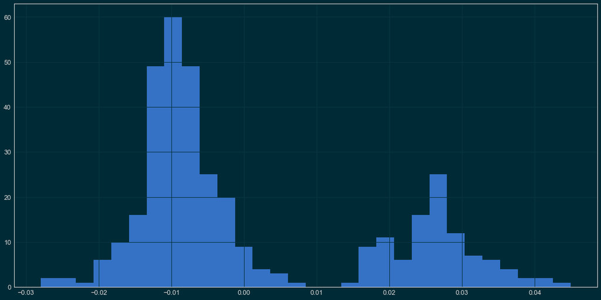

```python
weekly_price.hist(bins=30)
```

Let's separate working days from non-working days, to see if they correspond with the modes in the multi-modal distribution.

```python
weekly_price = weekly_price.reset_index().rename(columns={0: 'price'})
week_days = weekly_price.date.apply(lambda x:x.weekday())
working = list(range(0,4)) + [6]
weekend = [4, 5]
weekly_price['weekday'] = week_days
```

```python
weekly_price.head(10)
```

|  | date | price | weekday |
| --- | --- | --- | --- |
| 0 | 2016-01-04 | NaN | 0 |
| 1 | 2016-01-05 | NaN | 1 |
| 2 | 2016-01-06 | NaN | 2 |
| 3 | 2016-01-07 | NaN | 3 |
| 4 | 2016-01-08 | NaN | 4 |
| 5 | 2016-01-09 | NaN | 5 |
| 6 | 2016-01-10 | -0.004162 | 6 |
| 7 | 2016-01-11 | -0.007305 | 0 |
| 8 | 2016-01-12 | -0.007489 | 1 |
| 9 | 2016-01-13 | -0.006805 | 2 |

```python
def plot_wp_hists():
    (100 * weekly_price.price).hist(bins=30, label='all')
    (100 * weekly_price[weekly_price.weekday.isin(working)].price).hist(
        bins=30, label='working day')
    (100 * weekly_price[weekly_price.weekday.isin(weekend)].price).hist(
        bins=30, label='weekend')
    plt.legend()
    plt.title('Histogram of the percentual variation of price above the week mean.')
    plt.xlabel('Percentage of variation (%)')
    plt.ylabel('Number of cases')
```

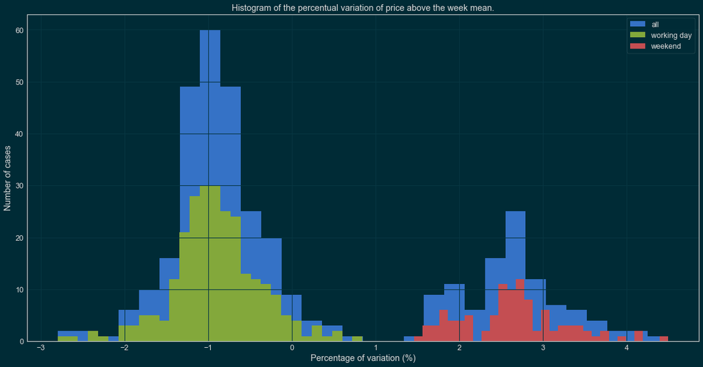

```python
plot_wp_hists()
```

Clearly the two modes of the distribution coincide with the working days and weekends. Let's look at that in the time variable.

```python
def plot_wp_trace():
    (100 * weekly_price.price).plot(label='all')
    (100 * weekly_price[weekly_price.weekday.isin(working)].price).plot(label='working day')
    (100 * weekly_price[weekly_price.weekday.isin(weekend)].price).plot(label='weekend')
    plt.legend()
    plt.title('Percent of variation above the week mean')
    plt.xlabel('Number of days since the begining of the data')
    plt.ylabel('Percentage of variation (%)')
```

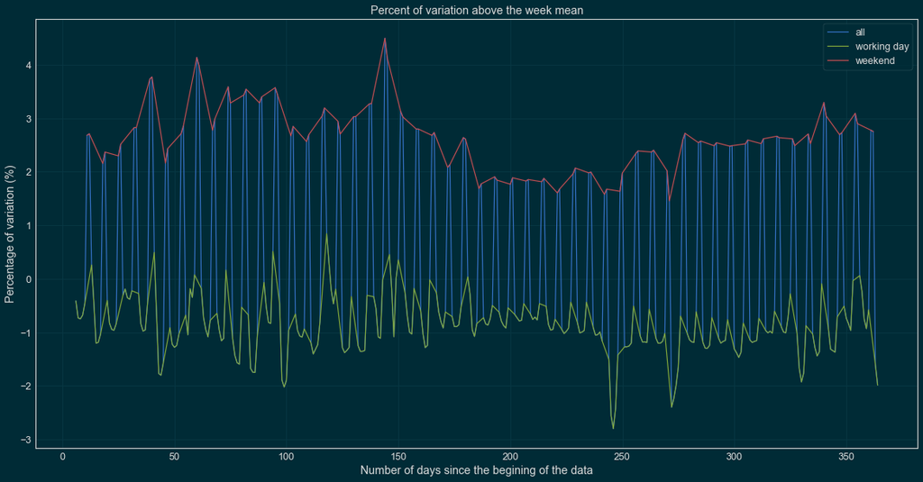

```python
plot_wp_trace()
```

Let's try to show both plots together.

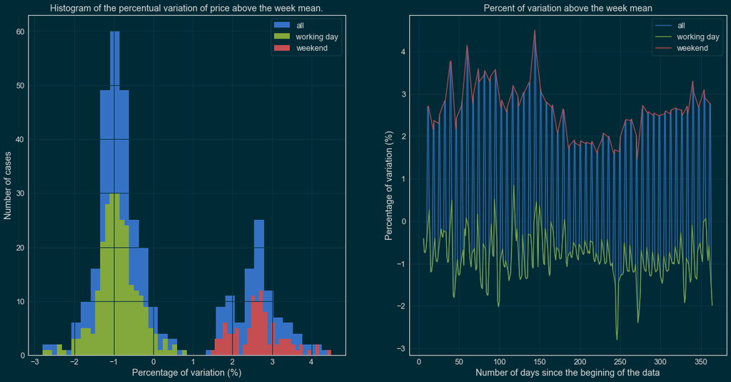

```python
rows, cols = (1, 2)
plt.subplot(rows, cols, 1)
plot_wp_hists()
plt.subplot(rows, cols, 2)
plot_wp_trace()
```

What about the mean inter-week deviations from the week mean?

```
Text(0,0.5,'Percentage of variation (%)')
```

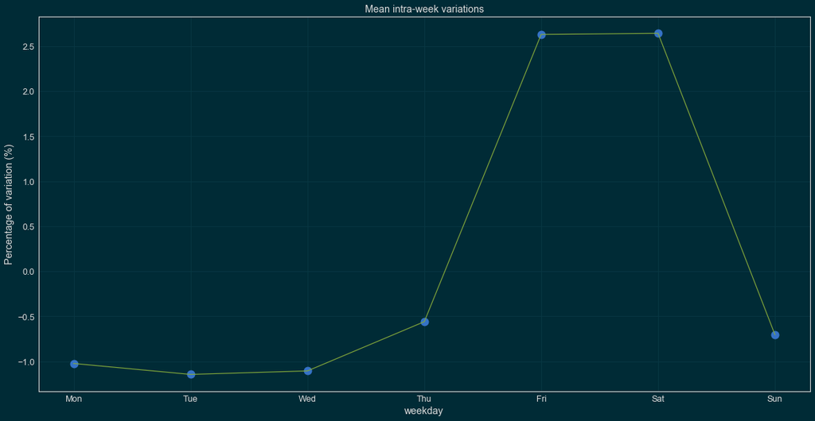

```python
mean_intra_frac = weekly_price.groupby('weekday').price.mean()
dow = ['Mon', 'Tue', 'Wed', 'Thu', 'Fri', 'Sat', 'Sun']
(100 * mean_intra_frac).plot(style='o', markersize=12)
(100 * mean_intra_frac).plot()
plt.xticks(mean_intra_frac.index, dow)
plt.title('Mean intra-week variations')
plt.ylabel('Percentage of variation (%)')
```

The "weekend" days, are in fact the days before a real weekend day, as the reservations include the night.

## Resuming, the price spike...

```python
frac_spike_rw = (week_mean.max() / week_mean.mean()) - 1.0
frac_spike_week = mean_intra_frac.max()
```

```python
total_spike = (1.0 + frac_spike_rw) * (1.0 + frac_spike_week) - 1.0
total_spike
```

```
0.09566565972578989
```

```python
print('If you choose to rent in the days between the begining of June and the' \
      +'begining of September the property will be, in mean, ' \
      '{:.2} % more expensive than the mean price.'.format(100 * frac_spike_rw)
     )
print()
print('If you choose to rent in a weekend, the property will be, in mean, ' \
      +'{:.2}% more expensive.'.format(100 * frac_spike_week))
print()

print('In total, you will probably be paying about {:.2}% '.format(
    100 * total_spike) + 'above the mean, by choosing the expensive days')
```

```
If you choose to rent in the days between the begining of June and thebegining of September the property will be, in mean, 6.7 % more expensive than the mean price.

If you choose to rent in a weekend, the property will be, in mean, 2.6% more expensive.

In total, you will probably be paying about 9.6% above the mean, by choosing the expensive days
```